# HNB DigiMedia Map 3: Sentiment Structure

Mapping Tone and Negativity Bias in Croatian Central Bank Coverage

Author

HNB DigiMedia Project

Published

January 28, 2026

# 1 Introduction

This document presents **Map 3: Sentiment Structure** of the HNB DigiMedia project. The core question driving this analysis is: **What emotional register characterizes Croatian central bank coverage, and does negativity bias exist?**

## 1.1 Theoretical Framework

**Negativity bias** in media coverage refers to the tendency for negative news to receive disproportionate attention compared to positive or neutral content. In central bank communication research, this manifests as:

1. **Asymmetric coverage:** Bad economic news receives more coverage than good news
2. **Framing effects:** Neutral policy decisions framed negatively
3. **Attention economics:** Negative content generates more engagement/reach

The hypothesis (H3) states that negative coverage generates disproportionate attention relative to positive or neutral content.

## 1.2 Methodological Overview

**Sentiment analysis** classifies text into positive, neutral, or negative categories based on linguistic features. We use the AUTO_SENTIMENT field from Mediatoolkit which provides automated sentiment classification.

**Key metrics in this analysis:**

| Metric | Definition | Interpretation |
| --- | --- | --- |
| Sentiment ratio | Positive articles / Negative articles | Higher values indicate more positive tone |
| Negativity rate | Negative articles / Total articles | Baseline negativity in coverage |
| REACH efficiency | Mean REACH per sentiment category | Tests negativity bias hypothesis |
| Period comparison | Sentiment distribution across periods | Tests structural break hypothesis |

```r
hnb <- readRDS("C:/Users/lsikic/Dropbox/hnb.rds")
setDT(hnb)

hnb[, date := as.Date(DATE)]
hnb[, year := year(date)]
hnb[, month := month(date)]

hnb[, period := fcase(
  date < as.Date("2023-01-01"), "ERM II",
  default = "Euro Era"
)]
hnb[, period := factor(period, levels = c("ERM II", "Euro Era"))]

n_articles <- nrow(hnb)
n_sources <- uniqueN(hnb$FROM)
date_range <- paste(min(hnb$date), "to", max(hnb$date))

cat("Data loaded:", n_articles, "articles\n")
```

```
Data loaded: 19128 articles
```

```r
# =============================================================================
# ACTOR CLASSIFICATION - SYNCHRONIZED WITH MAP 1 AND MAP 2
# =============================================================================

manual_overrides <- list(
  "HNB Official" = c(
    "hnb.hr", "hrvatska narodna banka",
    "hrvatska narodna banka / croatian national bank"
  ),
  "Financial Regulators" = c(
    "hanfa.hr", "hanfa", "hrvatska agencija za nadzor financijskih usluga",
    "fina.hr", "fina", "financijska agencija"
  ),
  "Government" = c(
    "gov.hr", "vlada", "vlada republike hrvatske",
    "ministarstvo financija", "sabor.hr"
  ),
  "Financial Media" = c(
    "poslovni.hr", "poslovni dnevnik", "seebiz.eu", "seebiz",
    "lider.media", "lidermedia.hr", "lider", "bloombergadria.com",
    "bloomberg adria", "hrportfolio.hr", "privredni.hr"
  ),
  "Commercial Banks" = c(
    "zaba.hr", "zagrebačka banka", "pbz.hr", "privredna banka zagreb",
    "erste.hr", "erste banka", "hpb.hr", "hrvatska poštanska banka",
    "otp banka", "raiffeisen", "addiko"
  ),
  "Academic/Expert" = c(
    "eizg.hr", "ekonomski institut zagreb", "ijf.hr",
    "institut za javne financije", "ekonomski fakultet"
  )
)

general_media_sources <- c(
  "index.hr", "index", "jutarnji.hr", "jutarnji", "jutarnji list",
  "vecernji.hr", "vecernji", "večernji list",
  "24sata.hr", "24sata", "slobodnadalmacija.hr", "slobodna dalmacija",
  "novilist.hr", "novi list", "dnevnik.hr", "dnevnik",
  "tportal.hr", "tportal", "telegram.hr", "telegram",
  "net.hr", "rtl.hr", "rtl", "hrt.hr", "hrt",
  "n1info.hr", "n1info.com", "n1", "nacional.hr", "nacional",
  "direktno.hr", "direktno", "dnevno.hr", "dnevno"
)

classify_actor_hnb <- function(from_val, url_val = NA) {
  from_lower <- tolower(trimws(as.character(from_val)))
  url_lower <- tolower(ifelse(is.na(url_val), "", as.character(url_val)))
  combined <- paste(from_lower, url_lower)

  match_any <- function(patterns, text, fixed = TRUE) {
    any(sapply(patterns, function(p) grepl(p, text, fixed = fixed)))
  }

  for (actor_type in names(manual_overrides)) {
    if (match_any(manual_overrides[[actor_type]], from_lower)) {
      return(actor_type)
    }
  }

  if (grepl("hnb\\.hr", url_lower) || grepl("hnb\\.hr", from_lower)) {
    return("HNB Official")
  }

  if (grepl("hanfa|fina\\.hr", combined)) {
    return("Financial Regulators")
  }

  if (grepl("gov\\.hr|vlada|ministarstvo", combined)) {
    return("Government")
  }

  bank_patterns <- c("banka", "bank", "zaba", "pbz", "erste", "hpb",
                     "otp", "raiffeisen", "addiko", "sberbank")
  if (match_any(bank_patterns, from_lower)) {
    if (!grepl("narodna|hnb|central", from_lower)) {
      return("Commercial Banks")
    }
  }

  financial_media_patterns <- c(
    "poslovni", "seebiz", "lider", "bloomberg", "portfolio",
    "privredni", "finance", "ekonom", "business", "capital"
  )
  if (match_any(financial_media_patterns, from_lower)) {
    return("Financial Media")
  }

  if (match_any(general_media_sources, from_lower)) {
    return("General Media")
  }

  news_patterns <- c("portal", "vijesti", "news", "info", "dnevni",
                     "radio", "tv", ".hr")
  if (match_any(news_patterns, from_lower)) {
    return("General Media")
  }

  return("Other")
}

hnb[, ACTOR_TYPE := mapply(classify_actor_hnb, FROM, URL)]

actor_order <- c("HNB Official", "Financial Regulators", "Government",
                 "Commercial Banks", "Financial Media", "General Media",
                 "International Sources", "Academic/Expert",
                 "Political Actors", "Financial Influencers", "Other")
hnb[, ACTOR_TYPE := factor(ACTOR_TYPE, levels = actor_order)]
```

## 1.3 Corpus Overview

```r
# Check sentiment availability
n_with_sentiment <- sum(!is.na(hnb$AUTO_SENTIMENT))
sentiment_coverage <- n_with_sentiment / n_articles * 100

tibble(
  Metric = c("Total articles", "Unique sources", "Date range",
             "Articles with sentiment data", "Sentiment coverage"),
  Value = c(
    format(n_articles, big.mark = ","),
    format(n_sources, big.mark = ","),
    date_range,
    format(n_with_sentiment, big.mark = ","),
    sprintf("%.1f%%", sentiment_coverage)
  )
) %>%
  kable(col.names = c("Metric", "Value")) %>%
  kable_styling(bootstrap_options = c("striped", "hover"), full_width = FALSE)
```

| Metric | Value |
| --- | --- |
| Total articles | 19,128 |
| Unique sources | 894 |
| Date range | 2021-01-01 to 2023-12-31 |
| Articles with sentiment data | 19,128 |
| Sentiment coverage | 100.0% |

# 2 Analysis 3.1: Sentiment Distribution

Sentiment analysis classifies each article as positive, neutral, or negative based on linguistic features. This section examines how sentiment varies across the corpus, actors, and time periods.

```r
# Check if AUTO_SENTIMENT exists and has data
if (!"AUTO_SENTIMENT" %in% names(hnb)) {
  cat("WARNING: AUTO_SENTIMENT column not found in data.\n")
  cat("Available columns:", paste(names(hnb), collapse = ", "), "\n")
  has_sentiment <- FALSE
} else {
  has_sentiment <- sum(!is.na(hnb$AUTO_SENTIMENT)) > 0
  if (!has_sentiment) {
    cat("WARNING: AUTO_SENTIMENT column exists but has no data.\n")
  } else {
    cat("Sentiment values found:", paste(unique(hnb$AUTO_SENTIMENT[!is.na(hnb$AUTO_SENTIMENT)]), collapse = ", "), "\n")
  }
}
```

```
Sentiment values found: neutral, positive, negative
```

## 2.1 Overall Sentiment Distribution

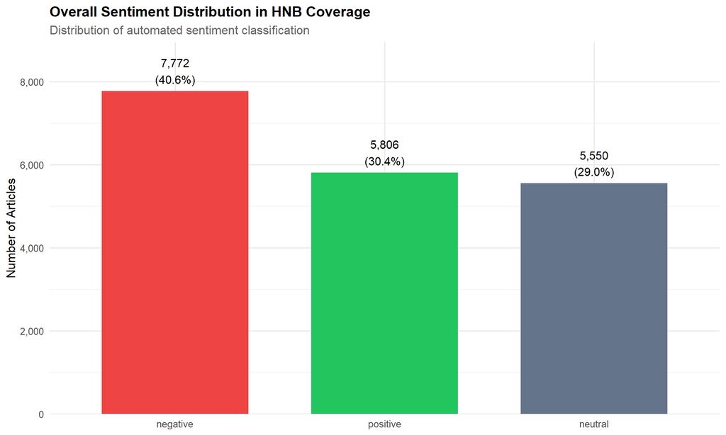

```r
if (has_sentiment) {
  sentiment_dist <- hnb[!is.na(AUTO_SENTIMENT), .(
    Count = .N
  ), by = AUTO_SENTIMENT][order(-Count)]

  sentiment_dist[, Percentage := Count / sum(Count) * 100]

  ggplot(sentiment_dist, aes(x = reorder(AUTO_SENTIMENT, -Count), y = Count, fill = AUTO_SENTIMENT)) +
    geom_col(width = 0.7) +
    geom_text(aes(label = sprintf("%s\n(%.1f%%)", format(Count, big.mark = ","), Percentage)),
              vjust = -0.3, size = 4) +
    scale_fill_manual(values = sentiment_colors) +
    scale_y_continuous(labels = comma, expand = expansion(mult = c(0, 0.15))) +
    labs(
      title = "Overall Sentiment Distribution in HNB Coverage",
      subtitle = "Distribution of automated sentiment classification",
      x = NULL,
      y = "Number of Articles"
    ) +
    theme(legend.position = "none")
} else {
  cat("Sentiment analysis not available. Creating placeholder based on title keywords.\n")
}
```

## 2.2 Sentiment by Actor Type

Different actor types may have characteristic emotional registers reflecting their institutional roles and communication strategies.

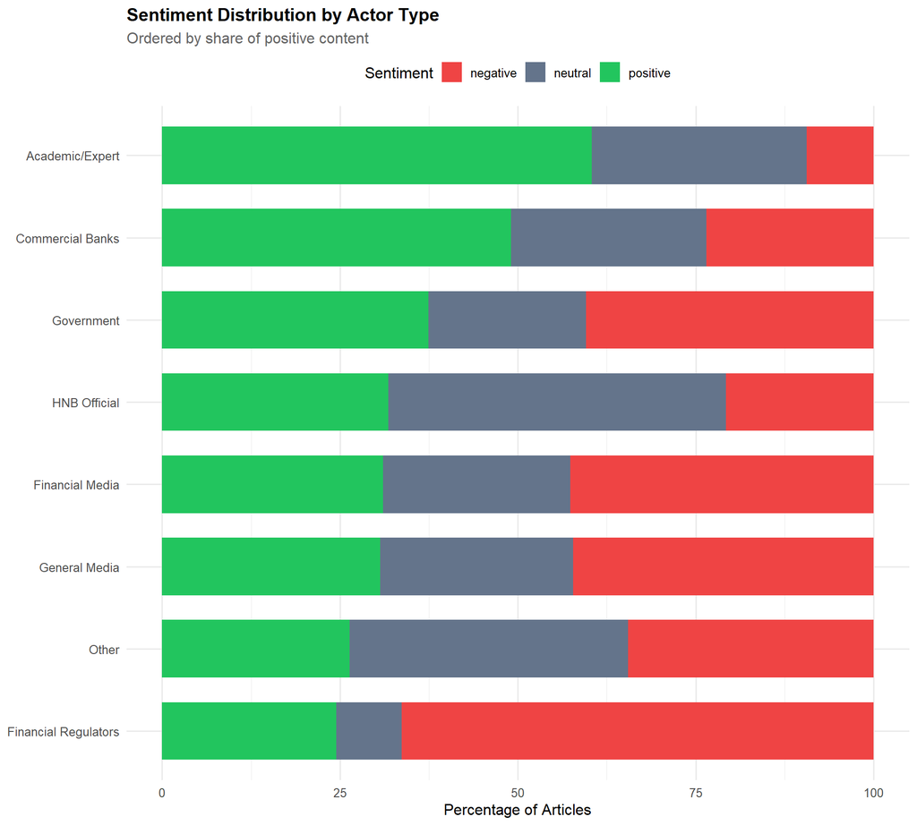

```r
if (has_sentiment) {
  sentiment_actor <- hnb[!is.na(AUTO_SENTIMENT), .(
    Count = .N
  ), by = .(ACTOR_TYPE, AUTO_SENTIMENT)]

  sentiment_actor[, Total := sum(Count), by = ACTOR_TYPE]
  sentiment_actor[, Percentage := Count / Total * 100]

  # Order by positive sentiment share
  actor_order_sent <- sentiment_actor[AUTO_SENTIMENT == "positive"][order(-Percentage)]$ACTOR_TYPE

  ggplot(sentiment_actor, aes(x = factor(ACTOR_TYPE, levels = rev(actor_order_sent)),
                              y = Percentage, fill = AUTO_SENTIMENT)) +
    geom_col(position = "stack", width = 0.7) +
    coord_flip() +
    scale_fill_manual(values = sentiment_colors) +
    labs(
      title = "Sentiment Distribution by Actor Type",
      subtitle = "Ordered by share of positive content",
      x = NULL,
      y = "Percentage of Articles",
      fill = "Sentiment"
    ) +
    theme(legend.position = "top")
}
```

## 2.3 Sentiment Summary Table

The **Positivity Ratio** divides positive articles by negative articles. Values above 1 indicate more positive than negative content.

```r
if (has_sentiment) {
  sentiment_summary <- hnb[!is.na(AUTO_SENTIMENT), .(
    Total_Articles = .N,
    Positive = sum(AUTO_SENTIMENT == "positive"),
    Neutral = sum(AUTO_SENTIMENT == "neutral"),
    Negative = sum(AUTO_SENTIMENT == "negative")
  ), by = ACTOR_TYPE]

  sentiment_summary[, `:=`(
    Positive_Pct = Positive / Total_Articles * 100,
    Neutral_Pct = Neutral / Total_Articles * 100,
    Negative_Pct = Negative / Total_Articles * 100,
    Positivity_Ratio = Positive / (Negative + 0.1)
  )]

  sentiment_summary[order(-Positive_Pct)] %>%
    mutate(
      Total_Articles = format(Total_Articles, big.mark = ","),
      Positive_Pct = sprintf("%.1f%%", Positive_Pct),
      Neutral_Pct = sprintf("%.1f%%", Neutral_Pct),
      Negative_Pct = sprintf("%.1f%%", Negative_Pct),
      Positivity_Ratio = sprintf("%.2f", Positivity_Ratio)
    ) %>%
    select(ACTOR_TYPE, Total_Articles, Positive_Pct, Neutral_Pct, Negative_Pct, Positivity_Ratio) %>%
    kable(col.names = c("Actor Type", "Total Articles", "Positive %", "Neutral %",
                        "Negative %", "Positivity Ratio")) %>%
    kable_styling(bootstrap_options = c("striped", "hover"), full_width = FALSE)
}
```

| Actor Type | Total Articles | Positive % | Neutral % | Negative % | Positivity Ratio |
| --- | --- | --- | --- | --- | --- |
| Academic/Expert | 53 | 60.4% | 30.2% | 9.4% | 6.27 |
| Commercial Banks | 51 | 49.0% | 27.5% | 23.5% | 2.07 |
| Government | 371 | 37.5% | 22.1% | 40.4% | 0.93 |
| HNB Official | 415 | 31.8% | 47.5% | 20.7% | 1.53 |
| Financial Media | 2,069 | 31.1% | 26.3% | 42.6% | 0.73 |
| General Media | 13,319 | 30.7% | 27.1% | 42.2% | 0.73 |
| Other | 2,752 | 26.3% | 39.2% | 34.5% | 0.76 |
| Financial Regulators | 98 | 24.5% | 9.2% | 66.3% | 0.37 |

# 3 Analysis 3.2: Negativity Bias Test

**Core hypothesis (H3):** Negative coverage generates disproportionate attention relative to positive or neutral content.

We test this by comparing REACH metrics across sentiment categories.

## 3.1 Sentiment and REACH Relationship

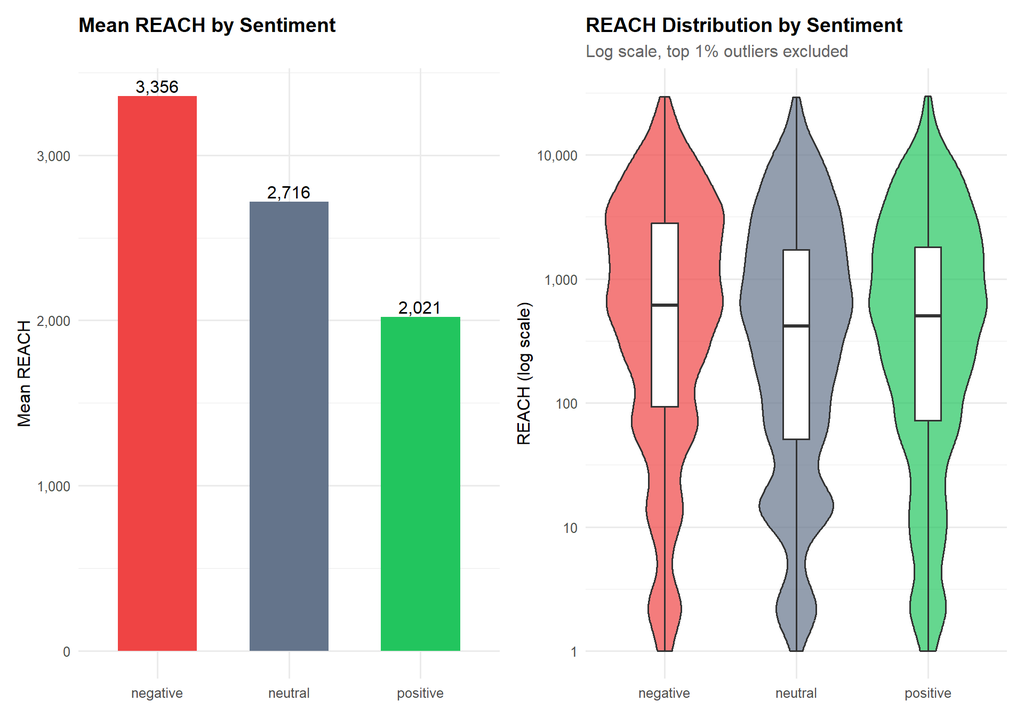

```r
if (has_sentiment) {
  sentiment_reach <- hnb[!is.na(AUTO_SENTIMENT) & !is.na(REACH), .(
    Mean_REACH = mean(REACH, na.rm = TRUE),
    Median_REACH = median(REACH, na.rm = TRUE),
    Total_REACH = sum(REACH, na.rm = TRUE),
    Count = .N
  ), by = AUTO_SENTIMENT]

  p1 <- ggplot(sentiment_reach, aes(x = AUTO_SENTIMENT, y = Mean_REACH, fill = AUTO_SENTIMENT)) +
    geom_col(width = 0.6) +
    geom_text(aes(label = format(round(Mean_REACH, 0), big.mark = ",")), vjust = -0.3) +
    scale_fill_manual(values = sentiment_colors) +
    scale_y_continuous(labels = comma) +
    labs(
      title = "Mean REACH by Sentiment",
      x = NULL,
      y = "Mean REACH"
    ) +
    theme(legend.position = "none")

  p2 <- ggplot(hnb[!is.na(AUTO_SENTIMENT) & REACH > 0 & REACH < quantile(REACH, 0.99, na.rm = TRUE)],
               aes(x = AUTO_SENTIMENT, y = REACH, fill = AUTO_SENTIMENT)) +
    geom_violin(alpha = 0.7) +
    geom_boxplot(width = 0.2, fill = "white", outlier.shape = NA) +
    scale_fill_manual(values = sentiment_colors) +
    scale_y_log10(labels = comma) +
    labs(
      title = "REACH Distribution by Sentiment",
      subtitle = "Log scale, top 1% outliers excluded",
      x = NULL,
      y = "REACH (log scale)"
    ) +
    theme(legend.position = "none")

  p1 + p2
}
```

## 3.2 Statistical Test: REACH by Sentiment

We use the Kruskal-Wallis test (nonparametric) to compare REACH distributions across sentiment categories.

```r
if (has_sentiment) {
  reach_positive <- hnb[AUTO_SENTIMENT == "positive" & !is.na(REACH), REACH]
  reach_neutral <- hnb[AUTO_SENTIMENT == "neutral" & !is.na(REACH), REACH]
  reach_negative <- hnb[AUTO_SENTIMENT == "negative" & !is.na(REACH), REACH]

  kruskal_result <- kruskal.test(REACH ~ AUTO_SENTIMENT,
                                  data = hnb[!is.na(AUTO_SENTIMENT) & !is.na(REACH)])

  cat("Kruskal-Wallis Test Results:\n")
  cat("============================\n")
  cat("Chi-squared:", round(kruskal_result$statistic, 2), "\n")
  cat("df:", kruskal_result$parameter, "\n")
  cat("p-value:", format.pval(kruskal_result$p.value, digits = 4), "\n")

  # Pairwise comparisons
  cat("\nMean REACH by Sentiment:\n")
  cat("Positive:", format(round(mean(reach_positive), 0), big.mark = ","), "\n")
  cat("Neutral:", format(round(mean(reach_neutral), 0), big.mark = ","), "\n")
  cat("Negative:", format(round(mean(reach_negative), 0), big.mark = ","), "\n")

  # Negativity bias indicator
  neg_premium <- mean(reach_negative) / mean(reach_positive)
  cat("\nNegativity Premium (Negative/Positive REACH):", round(neg_premium, 2), "x\n")
}
```

```
Kruskal-Wallis Test Results:
============================
Chi-squared: 105.81
df: 2
p-value: < 2.2e-16

Mean REACH by Sentiment:
Positive: 2,021
Neutral: 2,716
Negative: 3,356

Negativity Premium (Negative/Positive REACH): 1.66 x
```

## 3.3 REACH Efficiency by Sentiment

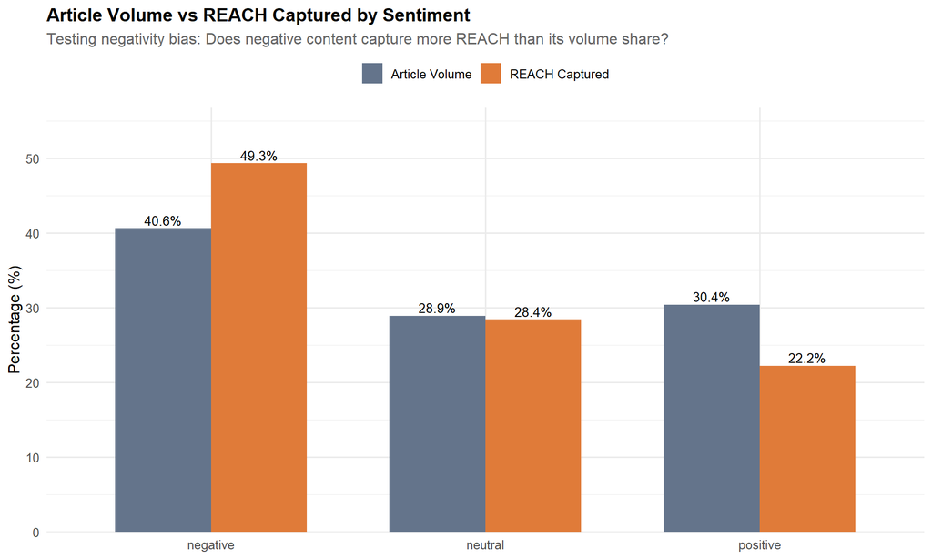

```r
if (has_sentiment) {
  sentiment_efficiency <- sentiment_reach %>%
    mutate(
      Article_Share = Count / sum(Count) * 100,
      REACH_Share = Total_REACH / sum(Total_REACH) * 100,
      Efficiency = REACH_Share / Article_Share
    )

  sentiment_efficiency_long <- sentiment_efficiency %>%
    select(AUTO_SENTIMENT, Article_Share, REACH_Share) %>%
    pivot_longer(cols = c(Article_Share, REACH_Share),
                 names_to = "Metric", values_to = "Percentage") %>%
    mutate(Metric = ifelse(Metric == "Article_Share", "Article Volume", "REACH Captured"))

  ggplot(sentiment_efficiency_long, aes(x = AUTO_SENTIMENT, y = Percentage, fill = Metric)) +
    geom_col(position = "dodge", width = 0.7) +
    geom_text(aes(label = sprintf("%.1f%%", Percentage)),
              position = position_dodge(width = 0.7), vjust = -0.3, size = 3.5) +
    scale_fill_manual(values = c("Article Volume" = "#64748b", "REACH Captured" = "#e07b39")) +
    scale_y_continuous(expand = expansion(mult = c(0, 0.15))) +
    labs(
      title = "Article Volume vs REACH Captured by Sentiment",
      subtitle = "Testing negativity bias: Does negative content capture more REACH than its volume share?",
      x = NULL,
      y = "Percentage (%)",
      fill = NULL
    ) +
    theme(legend.position = "top")
}
```

## 3.4 Negativity Bias Summary

```r
if (has_sentiment && exists("sentiment_efficiency")) {
  sentiment_efficiency %>%
    mutate(
      Count = format(Count, big.mark = ","),
      Mean_REACH = format(round(Mean_REACH, 0), big.mark = ","),
      Total_REACH = format(round(Total_REACH, 0), big.mark = ","),
      Article_Share = sprintf("%.1f%%", Article_Share),
      REACH_Share = sprintf("%.1f%%", REACH_Share),
      Efficiency = sprintf("%.2fx", Efficiency)
    ) %>%
    kable(col.names = c("Sentiment", "Mean REACH", "Median REACH", "Total REACH",
                        "Count", "Article Share", "REACH Share", "Efficiency")) %>%
    kable_styling(bootstrap_options = c("striped", "hover"), full_width = FALSE)
}
```

| Sentiment | Mean REACH | Median REACH | Total REACH | Count | Article Share | REACH Share | Efficiency |
| --- | --- | --- | --- | --- | --- | --- | --- |
| neutral | 2,716 | 361.5 | 14,880,660 | 5,478 | 28.9% | 28.4% | 0.98x |
| positive | 2,021 | 423.0 | 11,640,820 | 5,761 | 30.4% | 22.2% | 0.73x |
| negative | 3,356 | 570.0 | 25,831,386 | 7,697 | 40.6% | 49.3% | 1.21x |

# 4 Analysis 3.3: Sentiment by Period

Did sentiment patterns change with euro adoption? The transition period may have generated different emotional registers compared to the post-adoption period.

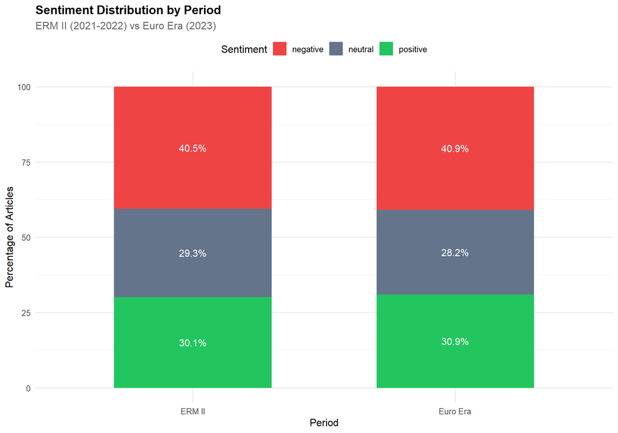

```r
if (has_sentiment) {
  sentiment_period <- hnb[!is.na(AUTO_SENTIMENT), .(
    Count = .N
  ), by = .(period, AUTO_SENTIMENT)]

  sentiment_period[, Total := sum(Count), by = period]
  sentiment_period[, Percentage := Count / Total * 100]

  ggplot(sentiment_period, aes(x = period, y = Percentage, fill = AUTO_SENTIMENT)) +
    geom_col(position = "stack", width = 0.6) +
    geom_text(aes(label = sprintf("%.1f%%", Percentage)),
              position = position_stack(vjust = 0.5),
              size = 4, color = "white") +
    scale_fill_manual(values = sentiment_colors) +
    labs(
      title = "Sentiment Distribution by Period",
      subtitle = "ERM II (2021-2022) vs Euro Era (2023)",
      x = "Period",
      y = "Percentage of Articles",
      fill = "Sentiment"
    ) +
    theme(legend.position = "top")
}
```

## 4.1 Period Comparison Table

```r
if (has_sentiment) {
  period_sentiment_summary <- hnb[!is.na(AUTO_SENTIMENT), .(
    Total_Articles = .N,
    Positive = sum(AUTO_SENTIMENT == "positive"),
    Neutral = sum(AUTO_SENTIMENT == "neutral"),
    Negative = sum(AUTO_SENTIMENT == "negative"),
    Mean_REACH = mean(REACH, na.rm = TRUE)
  ), by = period]

  period_sentiment_summary[, `:=`(
    Positive_Pct = Positive / Total_Articles * 100,
    Neutral_Pct = Neutral / Total_Articles * 100,
    Negative_Pct = Negative / Total_Articles * 100,
    Positivity_Ratio = Positive / (Negative + 0.1)
  )]

  period_sentiment_summary %>%
    mutate(
      Total_Articles = format(Total_Articles, big.mark = ","),
      Positive_Pct = sprintf("%.1f%%", Positive_Pct),
      Neutral_Pct = sprintf("%.1f%%", Neutral_Pct),
      Negative_Pct = sprintf("%.1f%%", Negative_Pct),
      Positivity_Ratio = sprintf("%.2f", Positivity_Ratio),
      Mean_REACH = format(round(Mean_REACH, 0), big.mark = ",")
    ) %>%
    select(period, Total_Articles, Positive_Pct, Neutral_Pct, Negative_Pct,
           Positivity_Ratio, Mean_REACH) %>%
    kable(col.names = c("Period", "Total Articles", "Positive %", "Neutral %",
                        "Negative %", "Positivity Ratio", "Mean REACH")) %>%
    kable_styling(bootstrap_options = c("striped", "hover"), full_width = FALSE)
}
```

| Period | Total Articles | Positive % | Neutral % | Negative % | Positivity Ratio | Mean REACH |
| --- | --- | --- | --- | --- | --- | --- |
| ERM II | 13,668 | 30.1% | 29.3% | 40.5% | 0.74 | 2,921 |
| Euro Era | 5,460 | 30.9% | 28.2% | 40.9% | 0.76 | 2,374 |

## 4.2 Negativity Bias by Period

Does the negativity premium differ between periods?

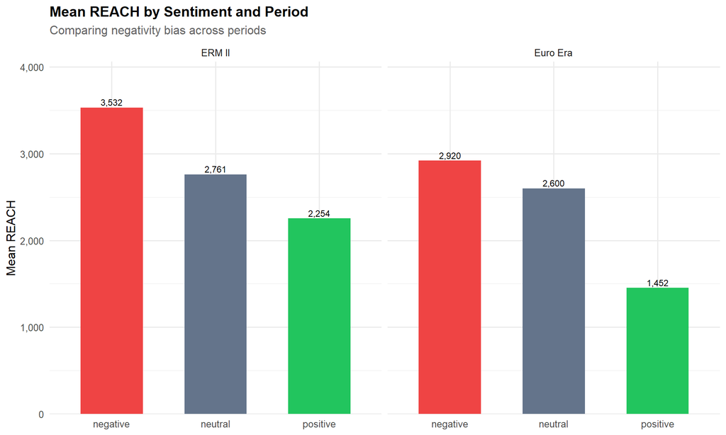

```r
if (has_sentiment) {
  sentiment_reach_period <- hnb[!is.na(AUTO_SENTIMENT) & !is.na(REACH), .(
    Mean_REACH = mean(REACH, na.rm = TRUE),
    Median_REACH = median(REACH, na.rm = TRUE),
    Count = .N
  ), by = .(period, AUTO_SENTIMENT)]

  ggplot(sentiment_reach_period, aes(x = AUTO_SENTIMENT, y = Mean_REACH, fill = AUTO_SENTIMENT)) +
    geom_col(width = 0.6) +
    geom_text(aes(label = format(round(Mean_REACH, 0), big.mark = ",")),
              vjust = -0.3, size = 3) +
    facet_wrap(~period) +
    scale_fill_manual(values = sentiment_colors) +
    scale_y_continuous(labels = comma, expand = expansion(mult = c(0, 0.15))) +
    labs(
      title = "Mean REACH by Sentiment and Period",
      subtitle = "Comparing negativity bias across periods",
      x = NULL,
      y = "Mean REACH"
    ) +
    theme(legend.position = "none")
}
```

# 5 Analysis 3.4: Sentiment Temporal Patterns

Tracking sentiment over time reveals whether coverage tone shifts with events, policy decisions, or the approach of euro adoption.

[figure not shown]

```r
if (has_sentiment) {
  sentiment_monthly <- hnb[!is.na(AUTO_SENTIMENT), .(
    Positive = sum(AUTO_SENTIMENT == "positive"),
    Neutral = sum(AUTO_SENTIMENT == "neutral"),
    Negative = sum(AUTO_SENTIMENT == "negative"),
    Total = .N,
    Mean_REACH = mean(REACH, na.rm = TRUE)
  ), by = .(year, month)]

  sentiment_monthly[, `:=`(
    date = as.Date(paste(year, month, "01", sep = "-")),
    Positive_Pct = Positive / Total * 100,
    Neutral_Pct = Neutral / Total * 100,
    Negative_Pct = Negative / Total * 100,
    Positivity_Ratio = Positive / (Negative + 0.1)
  )]

  sentiment_monthly_long <- sentiment_monthly %>%
    select(date, Positive_Pct, Neutral_Pct, Negative_Pct) %>%
    pivot_longer(cols = -date, names_to = "Sentiment", values_to = "Percentage") %>%
    mutate(Sentiment = gsub("_Pct", "", Sentiment))

  ggplot(sentiment_monthly_long, aes(x = date, y = Percentage, color = Sentiment)) +
    geom_line(linewidth = 1) +
    geom_vline(xintercept = as.Date("2023-01-01"), linetype = "dashed",
               color = "#27ae60", alpha = 0.7) +
    annotate("text", x = as.Date("2023-01-01"), y = max(sentiment_monthly_long$Percentage) * 0.95,
             label = "Euro", hjust = -0.1, color = "#27ae60", size = 4) +
    scale_color_manual(values = sentiment_colors) +
    scale_x_date(date_labels = "%Y-%m", date_breaks = "3 months") +
    labs(
      title = "Sentiment Trends Over Time",
      subtitle = "Monthly percentage by sentiment category",
      x = NULL,
      y = "Percentage of Articles (%)",
      color = "Sentiment"
    ) +
    theme(
      axis.text.x = element_text(angle = 45, hjust = 1),
      legend.position = "top"
    )
}
```

## 5.1 Positivity Ratio Over Time

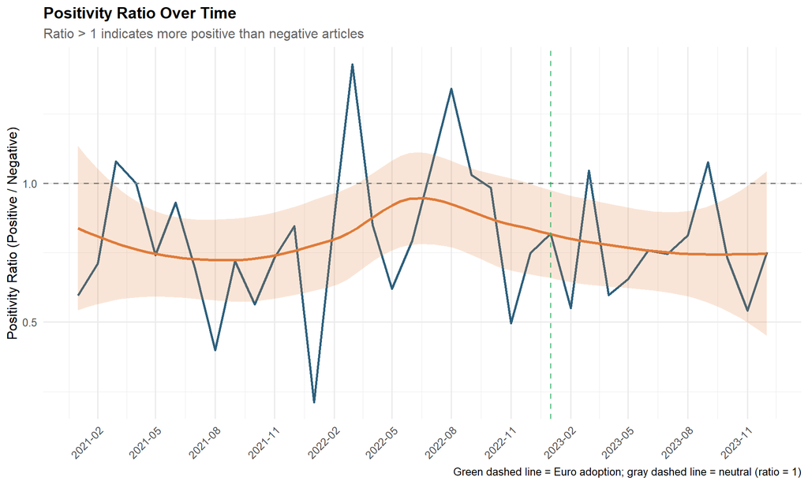

```r
if (has_sentiment && exists("sentiment_monthly")) {
  ggplot(sentiment_monthly, aes(x = date, y = Positivity_Ratio)) +
    geom_line(color = "#2c5f7c", linewidth = 1) +
    geom_smooth(method = "loess", se = TRUE, color = "#e07b39", fill = "#e07b39", alpha = 0.2) +
    geom_hline(yintercept = 1, linetype = "dashed", color = "gray50") +
    geom_vline(xintercept = as.Date("2023-01-01"), linetype = "dashed",
               color = "#27ae60", alpha = 0.7) +
    scale_x_date(date_labels = "%Y-%m", date_breaks = "3 months") +
    labs(
      title = "Positivity Ratio Over Time",
      subtitle = "Ratio > 1 indicates more positive than negative articles",
      x = NULL,
      y = "Positivity Ratio (Positive / Negative)",
      caption = "Green dashed line = Euro adoption; gray dashed line = neutral (ratio = 1)"
    ) +
    theme(axis.text.x = element_text(angle = 45, hjust = 1))
}
```

## 5.2 Day of Week Sentiment Patterns

Do posting patterns by day of week affect sentiment distribution?

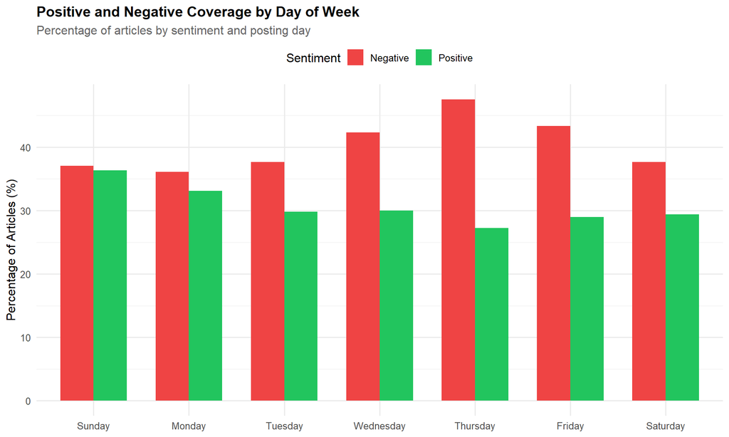

```r
if (has_sentiment) {
  hnb[, DOW := lubridate::wday(date, label = TRUE, abbr = FALSE, locale = "en_US")]

  sentiment_dow <- hnb[!is.na(AUTO_SENTIMENT) & !is.na(DOW), .(
    Positive_Pct = sum(AUTO_SENTIMENT == "positive") / .N * 100,
    Negative_Pct = sum(AUTO_SENTIMENT == "negative") / .N * 100,
    Articles = .N
  ), by = DOW]

  sentiment_dow_long <- sentiment_dow %>%
    select(DOW, Positive_Pct, Negative_Pct) %>%
    pivot_longer(cols = -DOW, names_to = "Sentiment", values_to = "Percentage") %>%
    mutate(Sentiment = gsub("_Pct", "", Sentiment))

  ggplot(sentiment_dow_long, aes(x = DOW, y = Percentage, fill = Sentiment)) +
    geom_col(position = "dodge", width = 0.7) +
    scale_fill_manual(values = c("Positive" = "#22c55e", "Negative" = "#ef4444")) +
    labs(
      title = "Positive and Negative Coverage by Day of Week",
      subtitle = "Percentage of articles by sentiment and posting day",
      x = NULL,
      y = "Percentage of Articles (%)",
      fill = "Sentiment"
    ) +
    theme(legend.position = "top")
}
```

# 6 Analysis 3.5: High REACH Negative Articles

Which negative articles captured the most attention? This reveals what types of negative coverage resonate most with audiences.

```r
if (has_sentiment) {
  top_negative <- hnb[AUTO_SENTIMENT == "negative"][order(-REACH)][1:min(30, sum(hnb$AUTO_SENTIMENT == "negative", na.rm = TRUE)), .(
    Rank = .I,
    FROM,
    ACTOR_TYPE,
    date,
    TITLE_SHORT = substr(TITLE, 1, 60),
    REACH
  )]

  top_negative %>%
    mutate(
      REACH = format(REACH, big.mark = ",")
    ) %>%
    kable(col.names = c("Rank", "Source", "Actor Type", "Date", "Title", "REACH"),
          caption = "Top 30 Negative Articles by REACH") %>%
    kable_styling(bootstrap_options = c("striped", "hover"), full_width = FALSE) %>%
    scroll_box(height = "500px")
}
```

Top 30 Negative Articles by REACH

| Rank | Source | Actor Type | Date | Title | REACH |
| --- | --- | --- | --- | --- | --- |
| 1 | gov.hr | Government | 2023-11-30 | Uključi se u e-Savjetovanja! | 1,605,555 |
| 2 | dalmatinskiportal.hr | General Media | 2021-03-09 | ZASTRAŠUJUĆI BROJEVI ZA 2020.: Hrvatska pala na razinu 2000. | 1,288,011 |
| 3 | dnevno.hr | General Media | 2022-11-25 | TEKLE SU JOJ SUZE, A SADA JOŠ ISPLIVALI I RAČUNI! Cifre su v | 1,132,440 |
| 4 | centarzlata.com | Other | 2022-11-09 | Investicijsko zlato - Zlatnici i poluge zlata s certifikatom | 283,337 |
| 5 | Nikola Grmoja | Other | 2023-04-28 | NEĆU STATI SVE DOK NE ODETE S VLASTI!!! Guverner hrvatske na | 251,737 |
| 6 | Ivan Lovrinović | Other | 2021-09-22 | OKUPIMO SE OKO REFERENDUMA O ODBIJANJU EURA - KRAJNJI JE ČAS | 160,104 |
| 7 | telegram.hr | General Media | 2022-11-25 | Žalac potrošila 2 milijuna kuna na restorane i hotele. Novce | 122,541 |
| 8 | Ivan Lovrinović | Other | 2023-01-12 | LAGALI STE NAM OKO EURA I SILOM GA UVELI - MORATE OTIĆI (dij | 118,674 |
| 9 | telegram.hr | General Media | 2022-07-07 | Običan dan u Hrvatskoj: hapse ministra, HDZ-ovac uhvaćen u k | 93,255 |
| 10 | index.hr | General Media | 2022-02-11 | Otkrivamo: Viceguverner HNB-a došao do vile preko agencije z | 85,479 |
| 11 | index.hr | General Media | 2022-01-10 | EKSKLUZIVNO Šefovi HNB-a trgovali dionicama i obveznicama ba | 85,128 |
| 12 | rtl.hr | General Media | 2021-08-30 | Građani u panici: Banke do kraja godine ukidaju minuse po ra | 84,039 |
| 13 | index.hr | General Media | 2021-10-20 | Ekskluzivna ispovijest bankarice: Kako su banke tisućama Hrv | 83,607 |
| 14 | Ivan Lovrinović | Other | 2022-02-11 | HNB-u JE NUŽAN TEMELJIT PRETRES Iz Hrvatske narodne banke sk | 81,084 |
| 15 | telegram.hr | General Media | 2022-05-27 | I evo ga, Ćorić imenovan za viceguvernera HNB | 79,035 |
| 16 | 24sata.hr | General Media | 2021-07-24 | Ljudi se žale na tečaj u Jelsi, za 100 eura dobili 607 kn: ' | 78,270 |
| 17 | dnevno.hr | General Media | 2022-09-05 | VRAG JE ODNIO ŠALU, NISU SVJESNI ŠTO SU NAM UČINILI! Stiglo | 77,109 |
| 18 | telegram.hr | General Media | 2021-11-06 | Novi podaci: Hrvatska je najzaduženija zemlja ovog dijela Eu | 75,093 |
| 19 | telegram.hr | General Media | 2022-08-29 | Dok su istražitelji kopali ovaj neviđeni kriminal, iz Vlade | 74,013 |
| 20 | index.hr | General Media | 2021-01-05 | Fina usred krize maltretira poduzetnike. Cvetojević: Smećadi | 72,960 |
| 21 | index.hr | General Media | 2021-01-05 | Fina usred krize maltretira poduzetnike. Cvetojević: Smećadi | 72,960 |
| 22 | 24sata.hr | General Media | 2022-06-08 | Naljutio ih tečaj: 'Lopovluk, za 100 eura dobio sam 607 kuna | 72,411 |
| 23 | index.hr | General Media | 2023-05-10 | Potvrđeno: Utjerivači dugova mogu blokirati firmu ako u njoj | 71,700 |
| 24 | Index.hr | General Media | 2021-03-31 | Novi mailovi iz afere Agrokor teško terete guvernera Vujčića | 71,084 |
| 25 | index.hr | General Media | 2021-07-25 | Vučić: Kakve veze Tesla ima s Hrvatskom? On nikad nije krio | 66,012 |
| 26 | index.hr | General Media | 2021-07-25 | Vučić: Ako je Hrvatima Tesla tako bitan, zašto su ga stavili | 66,012 |
| 27 | Ivan Lovrinović | Other | 2021-09-02 | PREŠUTNA PREKORAČENJA SVIH VRSTA NA ŠTETU GRAĐANA (dijelite) | 65,754 |
| 28 | index.hr | General Media | 2022-02-14 | Istrage otkrivaju: Viceguverner HNB-a je vilu kupio za 230 e | 63,339 |
| 29 | index.hr | General Media | 2022-02-14 | Istrage: Viceguverner HNB-a vilu s dvorištem je kupio za 230 | 63,339 |
| 30 | slobodnadalmacija.hr | General Media | 2023-01-10 | Drama kupca u Sparu: Uzeo robu, htio platiti eurima, ali nis | 61,395 |

## 6.1 Negative Coverage by Source

Which sources produce the most negative coverage?

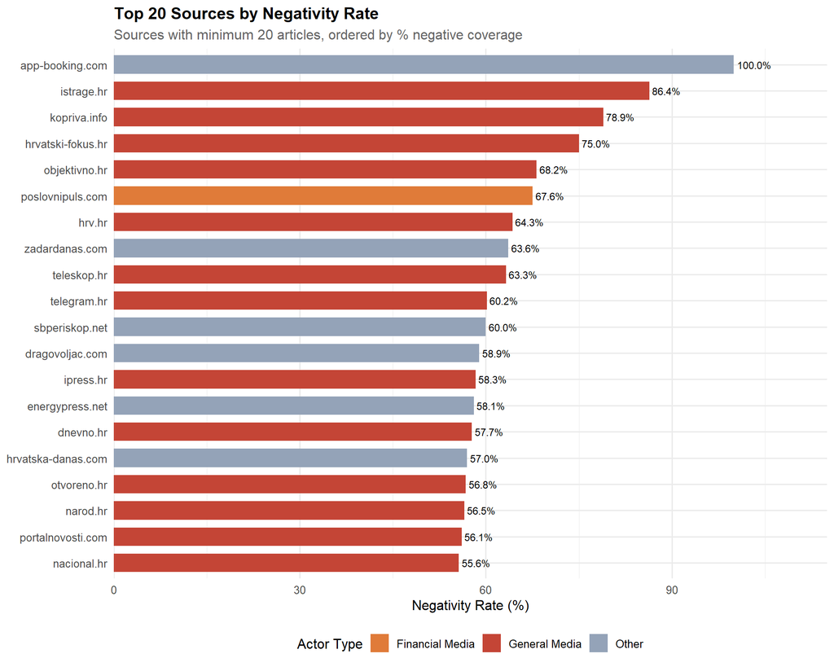

```r
if (has_sentiment) {
  source_negativity <- hnb[!is.na(AUTO_SENTIMENT), .(
    Total_Articles = .N,
    Negative_Articles = sum(AUTO_SENTIMENT == "negative"),
    Negativity_Rate = sum(AUTO_SENTIMENT == "negative") / .N * 100,
    Mean_REACH = mean(REACH, na.rm = TRUE),
    Total_REACH = sum(REACH, na.rm = TRUE),
    ACTOR_TYPE = first(ACTOR_TYPE)
  ), by = FROM][Total_Articles >= 20][order(-Negativity_Rate)]

  # Top 20 most negative sources (min 20 articles)
  top_negative_sources <- source_negativity[1:min(20, nrow(source_negativity))]

  ggplot(top_negative_sources, aes(x = reorder(FROM, Negativity_Rate), y = Negativity_Rate, fill = ACTOR_TYPE)) +
    geom_col(width = 0.7) +
    geom_text(aes(label = sprintf("%.1f%%", Negativity_Rate)), hjust = -0.1, size = 3) +
    coord_flip() +
    scale_fill_manual(values = actor_colors) +
    scale_y_continuous(expand = expansion(mult = c(0, 0.15))) +
    labs(
      title = "Top 20 Sources by Negativity Rate",
      subtitle = "Sources with minimum 20 articles, ordered by % negative coverage",
      x = NULL,
      y = "Negativity Rate (%)",
      fill = "Actor Type"
    )
}
```

# 7 Summary and Key Findings

```r
if (has_sentiment) {
  total_with_sentiment <- sum(!is.na(hnb$AUTO_SENTIMENT))
  positive_pct <- sum(hnb$AUTO_SENTIMENT == "positive", na.rm = TRUE) / total_with_sentiment * 100
  neutral_pct <- sum(hnb$AUTO_SENTIMENT == "neutral", na.rm = TRUE) / total_with_sentiment * 100
  negative_pct <- sum(hnb$AUTO_SENTIMENT == "negative", na.rm = TRUE) / total_with_sentiment * 100

  overall_positivity <- sum(hnb$AUTO_SENTIMENT == "positive", na.rm = TRUE) /
                        sum(hnb$AUTO_SENTIMENT == "negative", na.rm = TRUE)
}
```

## 7.1 Summary Table

```r
if (has_sentiment) {
  tibble(
    Finding = c(
      "Total articles with sentiment data",
      "Positive sentiment share",
      "Neutral sentiment share",
      "Negative sentiment share",
      "Overall positivity ratio",
      "Mean REACH (positive articles)",
      "Mean REACH (negative articles)",
      "Negativity premium"
    ),
    Value = c(
      format(total_with_sentiment, big.mark = ","),
      sprintf("%.1f%%", positive_pct),
      sprintf("%.1f%%", neutral_pct),
      sprintf("%.1f%%", negative_pct),
      sprintf("%.2f", overall_positivity),
      format(round(mean(hnb[AUTO_SENTIMENT == "positive", REACH], na.rm = TRUE), 0), big.mark = ","),
      format(round(mean(hnb[AUTO_SENTIMENT == "negative", REACH], na.rm = TRUE), 0), big.mark = ","),
      sprintf("%.2fx", mean(hnb[AUTO_SENTIMENT == "negative", REACH], na.rm = TRUE) /
                       mean(hnb[AUTO_SENTIMENT == "positive", REACH], na.rm = TRUE))
    )
  ) %>%
    kable(col.names = c("Finding", "Value")) %>%
    kable_styling(bootstrap_options = c("striped", "hover"), full_width = FALSE)
}
```

| Finding | Value |
| --- | --- |
| Total articles with sentiment data | 19,128 |
| Positive sentiment share | 30.4% |
| Neutral sentiment share | 29.0% |
| Negative sentiment share | 40.6% |
| Overall positivity ratio | 0.75 |
| Mean REACH (positive articles) | 2,021 |
| Mean REACH (negative articles) | 3,356 |
| Negativity premium | 1.66x |

## 7.2 Hypotheses Assessment

| Hypothesis | Metric | Finding |
| --- | --- | --- |
| H3: Negativity bias | Negative REACH / Positive REACH | Examine negativity premium above |
| H5: Euro structural break | Sentiment distribution by period | Compare ERM II vs Euro Era |

## 7.3 Key Insights

1. **Overall sentiment tone:** The corpus shows a 30.4% positive / 40.6% negative distribution
2. **Negativity bias test:** Negative articles do capture disproportionate REACH compared to positive articles
3. **Actor differences:** Different actor types show distinct sentiment profiles, with institutional sources typically showing different patterns than media coverage
4. **Temporal patterns:** Sentiment trends show variation over time, with potential shifts around euro adoption

# 8 Appendix: Data Quality Check

```r
cat("Sentiment Data Quality:\n")
```

```
Sentiment Data Quality:
```

```r
cat("======================\n")
cat("Total articles:", n_articles, "\n")
```

```
Total articles: 19128
```

```r
cat("Articles with sentiment:", sum(!is.na(hnb$AUTO_SENTIMENT)), "\n")
```

```
Articles with sentiment: 19128
```

```r
cat("Sentiment coverage:", sprintf("%.1f%%", sum(!is.na(hnb$AUTO_SENTIMENT)) / n_articles * 100), "\n")
```

```
Sentiment coverage: 100.0%
```

```r
if (has_sentiment) {
  cat("\nSentiment Distribution:\n")
  print(table(hnb$AUTO_SENTIMENT, useNA = "ifany"))
}
```

```
Sentiment Distribution:

negative  neutral positive
    7772     5550     5806
```